# SA LGA vax stats exploration

Ben Moretti

30 October 2021

# 1 Introduction

The South Australian Government has announced lifting of various COVID restrictions when the State reaches a vaccination rate of 80% overall, and then further restriction lifting at 90%. These figures made me wonder how much variation there is between the whole of state vaccination rate and those for Local Government Areas (Councils), and what sort of variation there is between LGAs. So the purpose of this is to look at some exploratory charts and statistics.

# 2 Data Gathering

For this exercise the data from the https://covid19nearme.com.au/vaccination-stats will be used. These excellent people have written scraper, parser and data visualisation code for all of the Australian governments’ COVID data. All of their code is published here https://github.com/jxeeno/aust-govt-covid19-vaccine-pdf and the collated vaccination data is published here https://vaccinedata.covid19nearme.com.au/data/geo/air_lga.csv in CSV format, and this is the source for this exercise.

First, the data will be read from the CSV file.

```r
# first some libraries
library(tidyverse)
library(janitor)
library(ggthemes)
library(ggrepel)
library(broom)
library(scales)
library(lubridate)

# read the data from csv and clean the names
air_tbl <- read_csv("https://vaccinedata.covid19nearme.com.au/data/geo/air_lga.csv") %>%
    clean_names()
```

Have a quick explore of the data

```r
air_tbl %>% glimpse()
```

```
## Rows: 5,410
## Columns: 17
## $ date_as_at                   <date> 2021-08-27, 2021-08-27, 2021-08-27, 2021…
## $ agg_level                    <chr> "ASGS_2020_LGA", "ASGS_2020_LGA", "ASGS_2…
## $ state                        <chr> "NSW", "NSW", "NSW", "NSW", "NSW", "NSW",…
## $ abs_code                     <dbl> 10050, 10180, 10250, 10300, 10470, 10500,…
## $ abs_name                     <chr> "Albury (C)", "Armidale Regional (A)", "B…
## $ age_lower                    <dbl> 15, 15, 15, 15, 15, 15, 15, 15, 15, 15, 1…
## $ age_upper                    <dbl> 999, 999, 999, 999, 999, 999, 999, 999, 9…
## $ air_first_dose_pct           <dbl> 58.9, 59.5, 62.4, 43.9, 58.6, 63.1, 70.2,…
## $ air_second_dose_pct          <dbl> 30.3, 31.7, 38.4, 27.2, 31.2, 30.8, 41.2,…
## $ air_first_dose_approx_count  <dbl> 25788, 15094, 23165, 816, 20575, 95121, 2…
## $ air_second_dose_approx_count <dbl> 13266, 8042, 14256, 506, 10955, 46430, 11…
## $ abs_erp_2019_population      <dbl> 43782, 25368, 37124, 1859, 35111, 150746,…
## $ masked                       <chr> "N", "N", "N", "N", "N", "N", "N", "N", "…
## $ sa4_code_2016                <chr> "109", "110;108", "112", "109", "103", "1…
## $ sa3_code_2016                <chr> "10901", "11001;10802;11002", "11201;1120…
## $ validated                    <chr> "Y", "Y", "Y", "Y", "Y", "Y", "Y", "Y", "…
## $ url                          <chr> "https://www.health.gov.au/sites/default/…
```

The columns of interest are

- `date_as_at`
- `state`
- `abs_name`
- `air_first_dose_pct`
- `air_second_dose_pct`
- `air_first_dose_approx_count`
- `air_second_dose_approx_count`
- `abs_erp_2019_population`

Select these into a data frame, filtering for only *SA* records.

```r
air_tidy_tbl <- air_tbl %>%
    filter(state == "SA") %>%
    select(date_as_at, state, abs_name, air_first_dose_pct:abs_erp_2019_population) %>%
    drop_na(air_second_dose_pct)

head(air_tidy_tbl)
```

```
## # A tibble: 6 × 8
##   date_as_at state abs_name  air_first_dose_p… air_second_dose… air_first_dose_…
##   <date>     <chr> <chr>                 <dbl>            <dbl>            <dbl>
## 1 2021-08-27 SA    Adelaide…              53               36.1            12728
## 2 2021-08-27 SA    Adelaide…              64.2             41.2            20833
## 3 2021-08-27 SA    Adelaide…              39               22.9             2906
## 4 2021-08-27 SA    Alexandr…              58.7             37.8            13666
## 5 2021-08-27 SA    Barossa …              59.9             39.3            12215
## 6 2021-08-27 SA    Barunga …              62               40.2             1368
## # … with 2 more variables: air_second_dose_approx_count <dbl>,
## #   abs_erp_2019_population <dbl>
```

Ok so the data is now good to move onto the next step

# 3 Exploration

As the data has a date column for the vaccination rate, this can be used to examine the change in rate over time. In the example below, the LGAs for Adelaide, Mt Gambier and Playford are selected and then their data plotted against date.

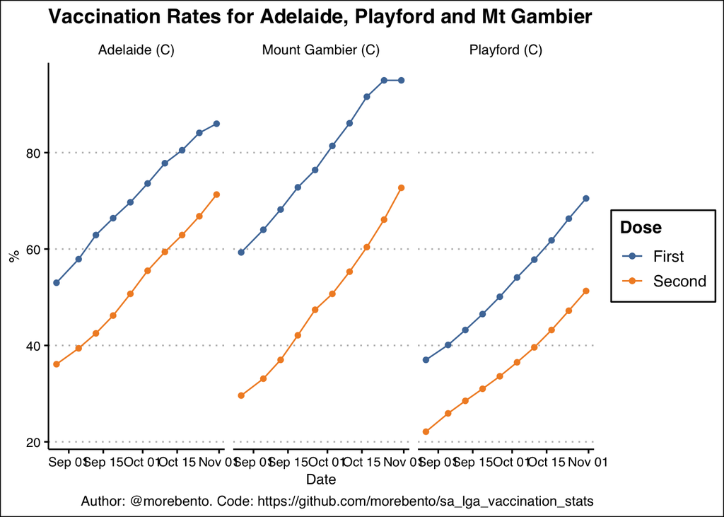

```r
# create a standard caption footer
plot_footer <- stringr::str_glue("Author: @morebento. Code: https://github.com/morebento/sa_lga_vaccination_stats")


air_tidy_tbl %>%
    filter(abs_name %in% c("Adelaide (C)", "Playford (C)", "Mount Gambier (C)")) %>%
    ggplot(aes(x=date_as_at)) +
    geom_line(aes(y=air_first_dose_pct, colour="First")) +
    geom_line(aes(y=air_second_dose_pct, colour="Second")) +
    geom_point(aes(y=air_first_dose_pct, colour="First")) +
    geom_point(aes(y=air_second_dose_pct, colour="Second")) +
    facet_wrap(vars(abs_name)) +
    theme_clean() + scale_colour_tableau() + # from ggthemes
    labs(
        title = "Vaccination Rates for Adelaide, Playford and Mt Gambier",
        x = "Date",
        y = "%",
        colour = "Dose",
        caption = plot_footer
    )
```

It can be seen that there is some variability in the vaccination rates at each date. This can be examined further by the use of a histogram to display the spread of LGAs by vaccination rate, and this is shown in the chart below.

The data has a time series, so the most recent values will need to be selected using the `slice_max` function from `dplyr`

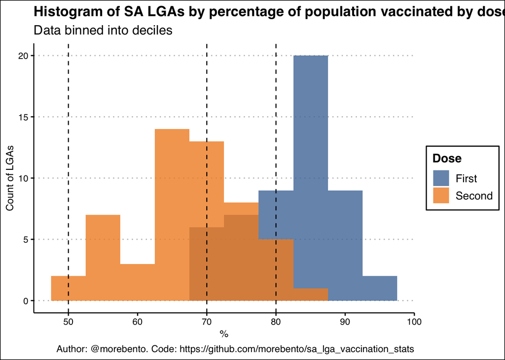

```r
air_tidy_tbl %>%
    slice_max(date_as_at) %>%
    select(abs_name, air_second_dose_pct, air_first_dose_pct) %>%
    pivot_longer(!abs_name, names_to = "metric", values_to = "value") %>%
    mutate(
        metric = case_when(
            metric == "air_first_dose_pct" ~ "First",
            metric == "air_second_dose_pct" ~ "Second"
        )
    ) %>%
    ggplot(aes(value)) +
    geom_histogram(aes(fill=metric), alpha=0.8, position="identity", bins = 10) +
    geom_vline(xintercept=50, linetype="dashed", aes(colour="lightgray")) +
    geom_vline(xintercept=70, linetype="dashed", aes(colour="lightgray")) +
    geom_vline(xintercept=80, linetype="dashed", aes(colour="lightgray")) +
    theme_clean() +
    scale_fill_tableau() + # from ggthemes
    labs(
        title = "Histogram of SA LGAs by percentage of population vaccinated by dose count",
        subtitle = "Data binned into deciles",
        caption = plot_footer,
        fill = "Dose",
        x = "%",
        y = "Count of LGAs"
    )
```

The histogram chart above displays vertical dashed lines for 50%, 70% and 80% vaccination rates. The data have been binned into deciles. The y-axis displays the count of LGAS within a particular bin.

As can be seen, there is quite a spread of values, with many LGAs below the 80% and indeed 70% vaccination rate for the second dose.

# 4 Hypothesis Formulation

A could of hypotheses can be made here

1. The spread of vaccination rates for LGAs varies widely
2. A particular LGAs vaccination % may be quite different from the state mean
3. the rate of increase of vaccination for a LGA is fairly constant and should able to be modelled and used to predict dates or vaccination levels

# 5 Modelling

Because the data have a time series, this can be used to forecast or predict future values, but because of the low number of records here more sophisticated models are not suitable, and thus the venerable *linear regression* will be used.

## 5.1 Predicting dates for certain vaccination levels

The first scenario which will be examined is the expected date at which certin vaccination levels will be reached, for example the date at which 80% will be vaccinated

### 5.1.1 Predicting dates for one LGA

Initially a model will be developed for a single LGA *Mount Gambier (C)*.

First the data needs to be selected and the dates converted to *epoch* format

```r
mt_gambier_tbl <- air_tidy_tbl %>%
    filter(abs_name == "Mount Gambier (C)") %>%

    # because of the quirks of dates we will be using epoch so the date needs to be
    # converted to the number of seconds since 1 January 1970
    mutate(
        date_as_at_epoch = as.integer(as.POSIXct(date_as_at))
    ) %>%
    select(air_second_dose_pct, date_as_at_epoch)


mt_gambier_tbl
```

```
## # A tibble: 10 × 2
##    air_second_dose_pct date_as_at_epoch
##                  <dbl>            <int>
##  1                29.6       1630022400
##  2                33.1       1630800000
##  3                37         1631404800
##  4                42.1       1632009600
##  5                47.4       1632614400
##  6                50.7       1633219200
##  7                55.3       1633824000
##  8                60.4       1634428800
##  9                66.1       1635033600
## 10                72.7       1635638400
```

Next, the data can be modelled using linear regression and the model examined

```r
lm_fit <- lm(date_as_at_epoch ~ air_second_dose_pct, data = mt_gambier_tbl)

summary(lm_fit)
```

```
##
## Call:
## lm(formula = date_as_at_epoch ~ air_second_dose_pct, data = mt_gambier_tbl)
##
## Residuals:
##     Min      1Q  Median      3Q     Max
## -311965  -21005   36098  113315  166828
##
## Coefficients:
##                      Estimate Std. Error t value Pr(>|t|)
## (Intercept)         1.627e+09  2.116e+05 7685.90  < 2e-16 ***
## air_second_dose_pct 1.293e+05  4.127e+03   31.33 1.17e-09 ***
## ---
## Signif. codes:  0 '***' 0.001 '**' 0.01 '*' 0.05 '.' 0.1 ' ' 1
##
## Residual standard error: 177400 on 8 degrees of freedom
## Multiple R-squared:  0.9919, Adjusted R-squared:  0.9909
## F-statistic: 981.4 on 1 and 8 DF,  p-value: 1.173e-09
```

The fitted and actual values can be plotted using the `augment` function from the `broom` package.

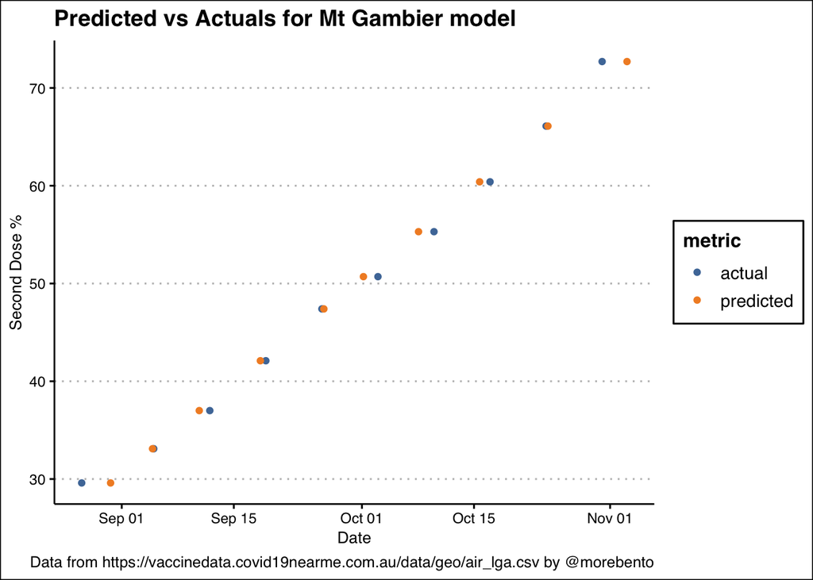

```r
augment(lm_fit) %>%
    rename(
        actual = date_as_at_epoch,
        predicted = `.fitted`
    ) %>%
    select(actual, predicted, air_second_dose_pct) %>%
    pivot_longer(!air_second_dose_pct, names_to ="metric", values_to = "datetime_epoch") %>%
    mutate(
        datetime = as_datetime(datetime_epoch)
    ) %>%
    ggplot() +
    geom_point(aes(x = datetime, y = air_second_dose_pct, colour= metric)) +
    scale_colour_tableau() +
    theme_clean() +
    labs(
        title = "Predicted vs Actuals for Mt Gambier model",
        caption = "Data from https://vaccinedata.covid19nearme.com.au/data/geo/air_lga.csv by @morebento",
        fill = "Dose",
        x = "Date",
        y = "Second Dose %"
    )
```

The model above is using the percentage of second dose vaccination to predict the date at which that might occur, using epoch.

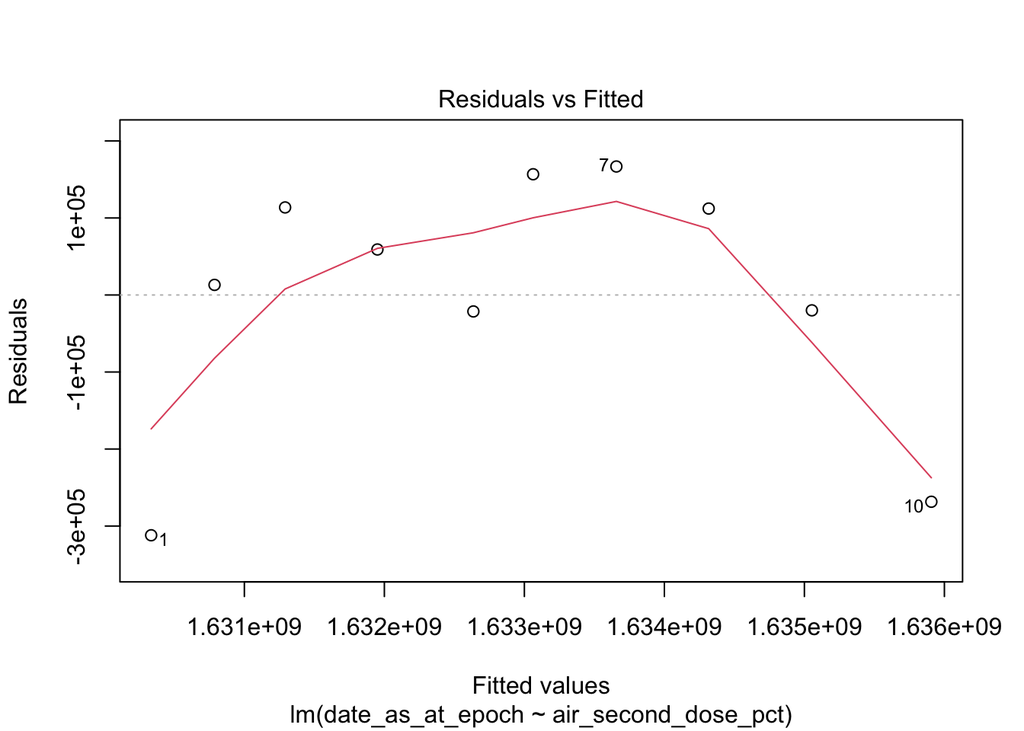

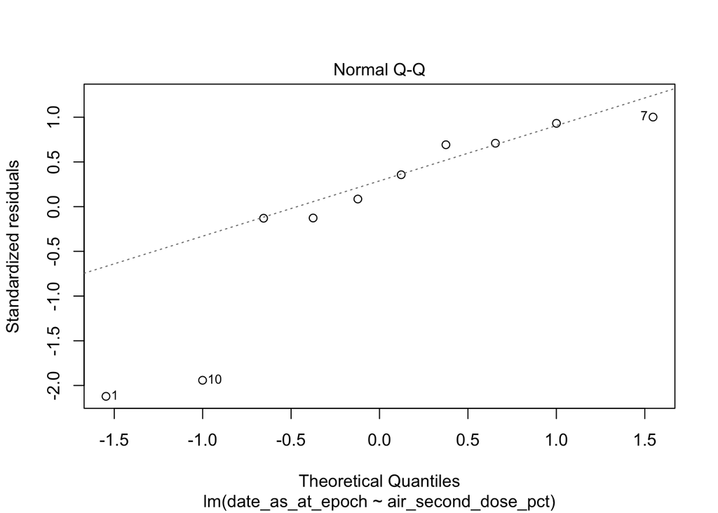

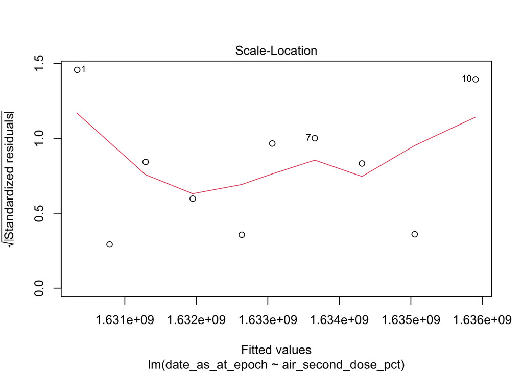

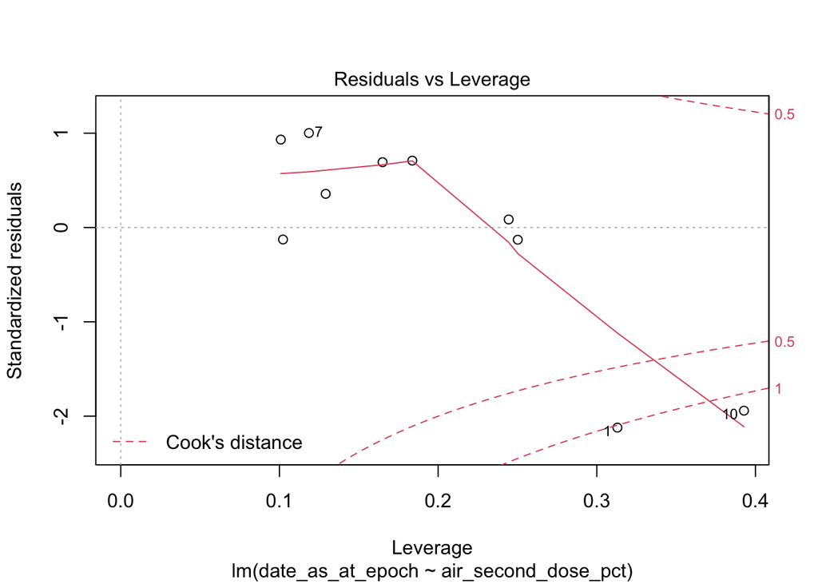

```r
plot(lm_fit)
```

The model can now be used to predict dates at which certain second dose % would be expected, as is shown in the below code.

```r
# date and time library
library(lubridate)

# define a data table of vaccination rates from 50% to 90%
p <- tribble(
    ~air_second_dose_pct,
    30,
    40,
    50,
    60,
    70,
    80,
    90
)

# predict against these values using the model converting to date time, cast to a data frame,
# add in the columns for the predictors and add a type column
predicted_tbl <- predict(lm_fit, newdata = p) %>%
    as_datetime() %>%
    as_tibble() %>%
    bind_cols(p) %>%
    mutate(
        type = "Predicted",
        date_as_at = value
    )

# for good measure also predict against the training set
predicted_actuals_tbl <- predict(lm_fit, newdata = mt_gambier_tbl)  %>%
    as_datetime() %>%
    as_tibble() %>%
    bind_cols(mt_gambier_tbl) %>%
    mutate(
        type = "Predicted Actual",
        date_as_at = value
    )


# add in the actual values for mt gambier
actuals_tbl <- mt_gambier_tbl %>%
    mutate(
        date_as_at = as_datetime(date_as_at_epoch),
        type = "Actual"
    )

# bind them together
combined_tbl <- bind_rows(predicted_tbl, actuals_tbl, predicted_actuals_tbl) %>%
    select(date_as_at, air_second_dose_pct, type)
```

The resulting data frame can now be plotted

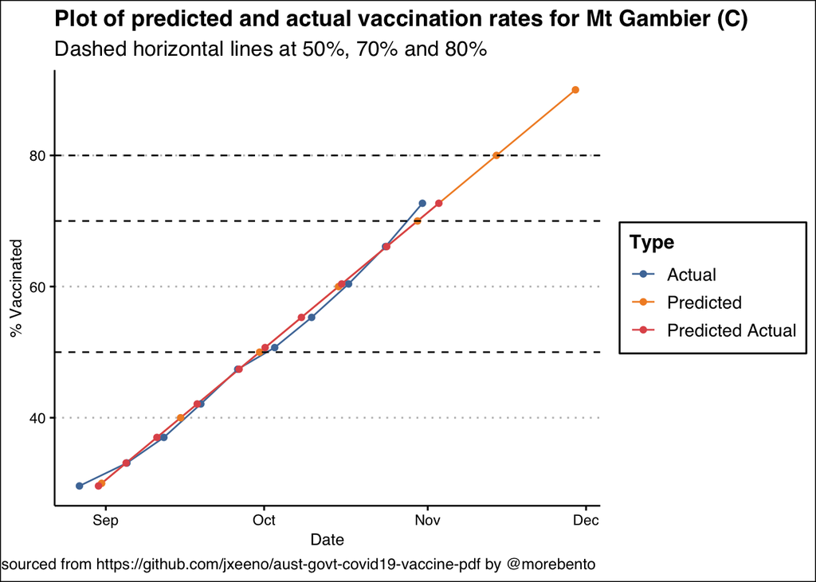

```r
combined_tbl %>%
    ggplot(aes(date_as_at, air_second_dose_pct)) +
    geom_line(aes(colour=type)) +
    geom_point(aes(colour=type)) +
    geom_hline(yintercept=50, linetype="dashed", aes(colour="lightgray")) +
    geom_hline(yintercept=70, linetype="dashed", aes(colour="lightgray")) +
    geom_hline(yintercept=80, linetype="dashed", aes(colour="lightgray")) +
    scale_colour_tableau() +
    theme_clean() +
    labs(
        title = "Plot of predicted and actual vaccination rates for Mt Gambier (C)",
        subtitle = "Dashed horizontal lines at 50%, 70% and 80%",
        caption =  "Data sourced from https://github.com/jxeeno/aust-govt-covid19-vaccine-pdf by @morebento ",
        colour = "Type",
        x = "Date",
        y = "% Vaccinated"
    )
```

### 5.1.2 Predicting dates for many LGAs

It can be seen that the modelling approach here is reasonably accurate, so it can be used to predict the dates at which certain vaccination rates for all of the LGAs in SA will be reached

First, the epoch column should be added to the entire data set and then it is nested

```r
air_nested_tbl <- air_tidy_tbl %>%
    mutate(
        date_as_at_epoch = as.integer(as.POSIXct(date_as_at))
    ) %>%
    select(abs_name, date_as_at_epoch, air_second_dose_pct) %>%
    group_by(abs_name) %>%
    nest()
```

Next, an anonymous function is used with `map` to take the nested data and perform the modelling run above

```r
air_nested_model_tbl <- air_nested_tbl %>%
    mutate(
        model = map(data, function(df) lm(date_as_at_epoch ~ air_second_dose_pct, data = df))
    )
```

The vaccination values to forecast to are defined above in the variable `p`

```r
p
```

```
## # A tibble: 7 × 1
##   air_second_dose_pct
##                 <dbl>
## 1                  30
## 2                  40
## 3                  50
## 4                  60
## 5                  70
## 6                  80
## 7                  90
```

These values can now be used to predict the dates at which the vaccination rates will be reached

```r
# here map is used to predict using the lga specific model against the predictors
# the predicted values are then joined back to the data frame
# finally the regression metrics are calculated via the glance function from the broom package

predicted_dates_tbl <- air_nested_model_tbl %>%
    mutate(
        prediction = map(.x = model, ~ predict(., p)),
        predictors = map(abs_name,  ~ bind_cols(p)),
        regression_metrics = map(.x = model, ~glance(.))
    )

predicted_dates_tbl
```

```
## # A tibble: 54 × 6
## # Groups:   abs_name [54]
##    abs_name               data     model prediction predictors  regression_metr…
##    <chr>                  <list>   <lis> <list>     <list>      <list>
##  1 Adelaide (C)           <tibble… <lm>  <dbl [7]>  <tibble [7… <tibble [1 × 12…
##  2 Adelaide Hills (DC)    <tibble… <lm>  <dbl [7]>  <tibble [7… <tibble [1 × 12…
##  3 Adelaide Plains (DC)   <tibble… <lm>  <dbl [7]>  <tibble [7… <tibble [1 × 12…
##  4 Alexandrina (DC)       <tibble… <lm>  <dbl [7]>  <tibble [7… <tibble [1 × 12…
##  5 Barossa (DC)           <tibble… <lm>  <dbl [7]>  <tibble [7… <tibble [1 × 12…
##  6 Barunga West (DC)      <tibble… <lm>  <dbl [7]>  <tibble [7… <tibble [1 × 12…
##  7 Berri and Barmera (DC) <tibble… <lm>  <dbl [7]>  <tibble [7… <tibble [1 × 12…
##  8 Burnside (C)           <tibble… <lm>  <dbl [7]>  <tibble [7… <tibble [1 × 12…
##  9 Campbelltown (C) (SA)  <tibble… <lm>  <dbl [7]>  <tibble [7… <tibble [1 × 12…
## 10 Charles Sturt (C)      <tibble… <lm>  <dbl [7]>  <tibble [7… <tibble [1 × 12…
## # … with 44 more rows
```

The regression metrics can how be unpacked from the data frame and used to plot a histogram, which shows the spread of Adjusted R Squared values.

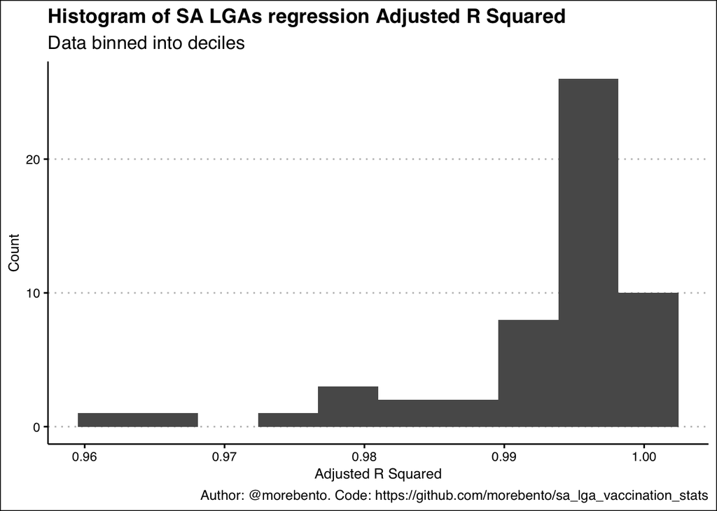

```r
predicted_dates_tbl %>%
    select(abs_name, regression_metrics) %>%
    unnest(regression_metrics) %>%
    ggplot(aes(adj.r.squared)) +
    geom_histogram(bins = 10) +
    theme_clean() +
    scale_fill_tableau() + # from ggthemes
    labs(
        title = "Histogram of SA LGAs regression Adjusted R Squared",
        subtitle = "Data binned into deciles",
        caption = plot_footer,
        x = "Adjusted R Squared",
        y = "Count"
    )
```

The data can now be tidied into a format which can be reused.

```r
predicted_dates_tidy_tbl <- predicted_dates_tbl %>%
    select(abs_name, prediction, predictors) %>%
    unnest() %>%
    mutate(
        date_as_at = round_date(as_datetime(prediction), "day")
    ) %>%
    select(-prediction) %>%
    mutate(
        type = "Predicted"
    )

# preview
predicted_dates_tidy_tbl
```

```
## # A tibble: 378 × 4
## # Groups:   abs_name [54]
##    abs_name            air_second_dose_pct date_as_at          type
##    <chr>                             <dbl> <dttm>              <chr>
##  1 Adelaide (C)                         30 2021-08-19 00:00:00 Predicted
##  2 Adelaide (C)                         40 2021-09-06 00:00:00 Predicted
##  3 Adelaide (C)                         50 2021-09-24 00:00:00 Predicted
##  4 Adelaide (C)                         60 2021-10-12 00:00:00 Predicted
##  5 Adelaide (C)                         70 2021-10-30 00:00:00 Predicted
##  6 Adelaide (C)                         80 2021-11-16 00:00:00 Predicted
##  7 Adelaide (C)                         90 2021-12-04 00:00:00 Predicted
##  8 Adelaide Hills (DC)                  30 2021-08-06 00:00:00 Predicted
##  9 Adelaide Hills (DC)                  40 2021-08-24 00:00:00 Predicted
## 10 Adelaide Hills (DC)                  50 2021-09-10 00:00:00 Predicted
## # … with 368 more rows
```

The predicted values can now be joined back to the actual data

```r
combined_tbl <- air_tidy_tbl %>%
    select(date_as_at, abs_name, air_second_dose_pct) %>%
    mutate(
        type = "Actual"
    ) %>%
    bind_rows(
        predicted_dates_tidy_tbl
    ) %>%
    arrange(
        abs_name, date_as_at
    )

combined_tbl
```

```
## # A tibble: 914 × 4
##    date_as_at          abs_name     air_second_dose_pct type
##    <dttm>              <chr>                      <dbl> <chr>
##  1 2021-08-19 00:00:00 Adelaide (C)                30   Predicted
##  2 2021-08-27 00:00:00 Adelaide (C)                36.1 Actual
##  3 2021-09-05 00:00:00 Adelaide (C)                39.4 Actual
##  4 2021-09-06 00:00:00 Adelaide (C)                40   Predicted
##  5 2021-09-12 00:00:00 Adelaide (C)                42.5 Actual
##  6 2021-09-19 00:00:00 Adelaide (C)                46.2 Actual
##  7 2021-09-24 00:00:00 Adelaide (C)                50   Predicted
##  8 2021-09-26 00:00:00 Adelaide (C)                50.7 Actual
##  9 2021-10-03 00:00:00 Adelaide (C)                55.5 Actual
## 10 2021-10-10 00:00:00 Adelaide (C)                59.4 Actual
## # … with 904 more rows
```

The actual and predicted data are now combined into a single data frame. This will be saved as `rds` data file in the `data` directory

```r
combined_tbl %>% write_rds("data/combined_date_forecast.rds")
```

## 5.2 Predicting vaccination rates

The above method uses regression to predict the dates at which certain vaccination rates will be reached. It is also necessary to predict the expected vaccination rates for LGAs at the expected opening day of *23 November 2021*. In this scenario, the same sequence of operations and indeed data will be used, however the regression formula will in effect be reversed

```r
# the same data will be used but the formula reversed, allowing the vax rate to be predicted at a given date
air_nested_reversed_model_tbl <- air_nested_tbl %>%
    mutate(
        model = map(data, function(df) lm(air_second_dose_pct ~ date_as_at_epoch, data = df))
    )

# this gives a column of lm models
air_nested_reversed_model_tbl
```

```
## # A tibble: 54 × 3
## # Groups:   abs_name [54]
##    abs_name               data              model
##    <chr>                  <list>            <list>
##  1 Adelaide (C)           <tibble [10 × 2]> <lm>
##  2 Adelaide Hills (DC)    <tibble [10 × 2]> <lm>
##  3 Adelaide Plains (DC)   <tibble [10 × 2]> <lm>
##  4 Alexandrina (DC)       <tibble [10 × 2]> <lm>
##  5 Barossa (DC)           <tibble [10 × 2]> <lm>
##  6 Barunga West (DC)      <tibble [10 × 2]> <lm>
##  7 Berri and Barmera (DC) <tibble [10 × 2]> <lm>
##  8 Burnside (C)           <tibble [10 × 2]> <lm>
##  9 Campbelltown (C) (SA)  <tibble [10 × 2]> <lm>
## 10 Charles Sturt (C)      <tibble [10 × 2]> <lm>
## # … with 44 more rows
```

The epoch value for the 23rd of November 2021 is calculated – this will be the predictor

```r
# convert the opening day date into epoch then cast to a dataframe with the expected column names
opening_day_tbl <- as.integer(as.POSIXct("2021-11-23")) %>%
    as_tibble() %>%
    rename(date_as_at_epoch = value)
```

This predictor data frame can now be used to predict, bind the predicted columns back to the predictors, and calculate the regression metrics

```r
predicted_vax_rates_tbl <- air_nested_reversed_model_tbl %>%
    mutate(
        prediction = map(.x = model, ~ predict(., opening_day_tbl)),
        predictors = map(abs_name,  ~ bind_cols(opening_day_tbl)),
        regression_metrics = map(.x = model, ~glance(.))
    )

# this returns a dataframe with the regression metrics, predictions and predictors
predicted_vax_rates_tbl
```

```
## # A tibble: 54 × 6
## # Groups:   abs_name [54]
##    abs_name               data     model prediction predictors  regression_metr…
##    <chr>                  <list>   <lis> <list>     <list>      <list>
##  1 Adelaide (C)           <tibble… <lm>  <dbl [1]>  <tibble [1… <tibble [1 × 12…
##  2 Adelaide Hills (DC)    <tibble… <lm>  <dbl [1]>  <tibble [1… <tibble [1 × 12…
##  3 Adelaide Plains (DC)   <tibble… <lm>  <dbl [1]>  <tibble [1… <tibble [1 × 12…
##  4 Alexandrina (DC)       <tibble… <lm>  <dbl [1]>  <tibble [1… <tibble [1 × 12…
##  5 Barossa (DC)           <tibble… <lm>  <dbl [1]>  <tibble [1… <tibble [1 × 12…
##  6 Barunga West (DC)      <tibble… <lm>  <dbl [1]>  <tibble [1… <tibble [1 × 12…
##  7 Berri and Barmera (DC) <tibble… <lm>  <dbl [1]>  <tibble [1… <tibble [1 × 12…
##  8 Burnside (C)           <tibble… <lm>  <dbl [1]>  <tibble [1… <tibble [1 × 12…
##  9 Campbelltown (C) (SA)  <tibble… <lm>  <dbl [1]>  <tibble [1… <tibble [1 × 12…
## 10 Charles Sturt (C)      <tibble… <lm>  <dbl [1]>  <tibble [1… <tibble [1 × 12…
## # … with 44 more rows
```

As previously the predictors and prediction can be retrieved and tidied into a usable format

```r
predicted_vax_rates_tidy_tbl <- predicted_vax_rates_tbl %>%
    select(abs_name, prediction, predictors) %>%
    unnest() %>%
    mutate(
        date_as_at = round_date(as_datetime(date_as_at_epoch), "day")
    ) %>%
    select(-date_as_at_epoch) %>%
    mutate(
        type = "Predicted"
    ) %>%
    rename(
        air_second_dose_pct = prediction
    ) %>%
    ungroup()

# preview
predicted_vax_rates_tidy_tbl
```

```
## # A tibble: 54 × 4
##    abs_name               air_second_dose_pct date_as_at          type
##    <chr>                                <dbl> <dttm>              <chr>
##  1 Adelaide (C)                          83.3 2021-11-23 00:00:00 Predicted
##  2 Adelaide Hills (DC)                   91.1 2021-11-23 00:00:00 Predicted
##  3 Adelaide Plains (DC)                  61.2 2021-11-23 00:00:00 Predicted
##  4 Alexandrina (DC)                      78.4 2021-11-23 00:00:00 Predicted
##  5 Barossa (DC)                          83.7 2021-11-23 00:00:00 Predicted
##  6 Barunga West (DC)                     81.4 2021-11-23 00:00:00 Predicted
##  7 Berri and Barmera (DC)                72.9 2021-11-23 00:00:00 Predicted
##  8 Burnside (C)                          96.2 2021-11-23 00:00:00 Predicted
##  9 Campbelltown (C) (SA)                 80.9 2021-11-23 00:00:00 Predicted
## 10 Charles Sturt (C)                     74.9 2021-11-23 00:00:00 Predicted
## # … with 44 more rows
```

```r
predicted_dates_tbl %>%
    select(abs_name, regression_metrics) %>%
    unnest(regression_metrics)
```

```
## # A tibble: 54 × 13
## # Groups:   abs_name [54]
##    abs_name r.squared adj.r.squared  sigma statistic  p.value    df logLik   AIC
##    <chr>        <dbl>         <dbl>  <dbl>     <dbl>    <dbl> <dbl>  <dbl> <dbl>
##  1 Adelaid…     0.996         0.995 1.29e5     1871. 9.01e-11     1  -131.  267.
##  2 Adelaid…     0.999         0.999 6.92e4     6499. 6.25e-13     1  -125.  255.
##  3 Adelaid…     0.993         0.992 1.68e5     1093. 7.66e-10     1  -133.  273.
##  4 Alexand…     0.998         0.998 9.12e4     3735. 5.71e-12     1  -127.  261.
##  5 Barossa…     0.998         0.998 8.52e4     4285. 3.30e-12     1  -127.  259.
##  6 Barunga…     0.965         0.961 3.70e5      220. 4.20e- 7     1  -141.  289.
##  7 Berri a…     0.986         0.984 2.35e5      556. 1.11e- 8     1  -137.  279.
##  8 Burnsid…     0.998         0.998 8.09e4     4756. 2.18e-12     1  -126.  258.
##  9 Campbel…     0.996         0.995 1.28e5     1902. 8.43e-11     1  -131.  267.
## 10 Charles…     0.997         0.997 9.93e4     3148. 1.13e-11     1  -128.  262.
## # … with 44 more rows, and 4 more variables: BIC <dbl>, deviance <dbl>,
## #   df.residual <int>, nobs <int>
```

# 6 Visualisation

Now that predictions have been made for the dates at which certain vaccination rates are reached, and for the vaccination rate expected on the 23rd of November 2021, then these can be visualised

## 6.1 Forecast and Actual Growth Chart

This chart shows the predicted and actual dates at which the vaccination rates will be reached

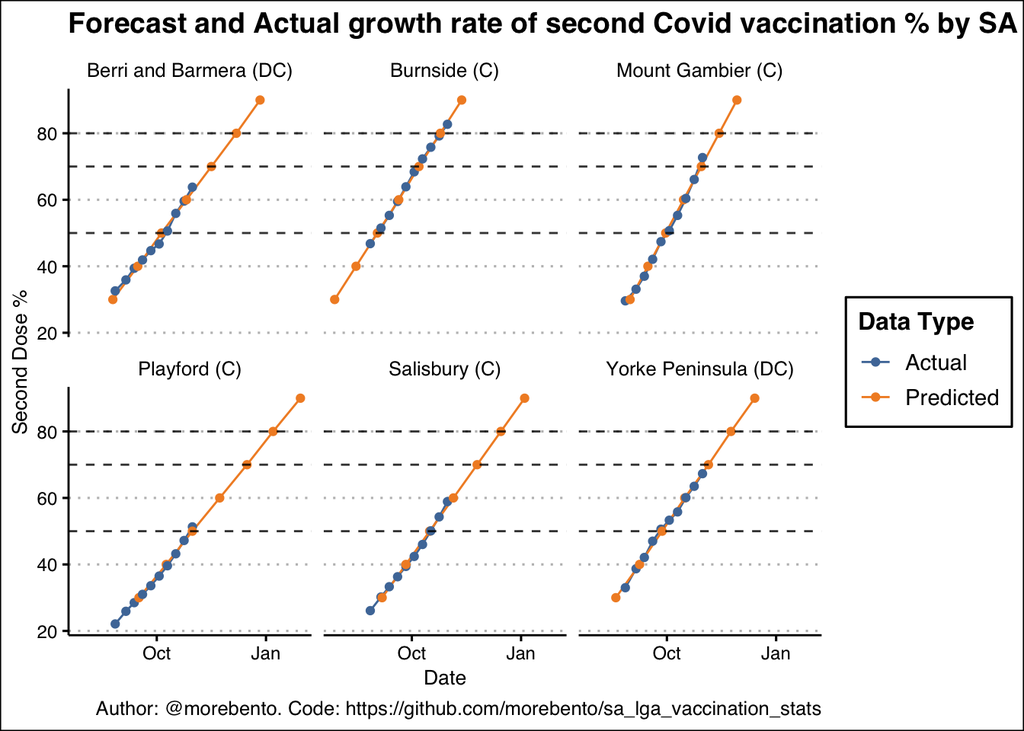

```r
combined_tbl %>%
    filter(
        abs_name %in% c("Playford (C)", "Burnside (C)", "Berri and Barmera (DC)", "Mount Gambier (C)", "Salisbury (C)", "Yorke Peninsula (DC)")
    ) %>%
    ggplot(aes(date_as_at, air_second_dose_pct)) +
    geom_line(aes(colour=type)) +
    geom_point(aes(colour=type)) +
    geom_hline(yintercept = 50, alpha=0.8, linetype="dashed") +
    geom_hline(yintercept = 70,alpha=0.8, linetype="dashed") +
    geom_hline(yintercept = 80, alpha=0.8, linetype="dashed") +
    geom_vline(xintercept=as.numeric(as.Date("2021-11-23")), linetype="dashed") +
    facet_wrap(vars(abs_name)) +
    theme_clean() +
    scale_colour_tableau() + # from ggthemes
    labs(
        title = "Forecast and Actual growth rate of second Covid vaccination % by SA LGA",
        caption =  plot_footer,
        y = "Second Dose %",
        x = "Date",
        colour = "Data Type"
    )
```

## 6.2 Expected rates for differing LGAs chart

This chart also shows the predicted and actual dates at which the defined vaccination rates will be reached, in a different format

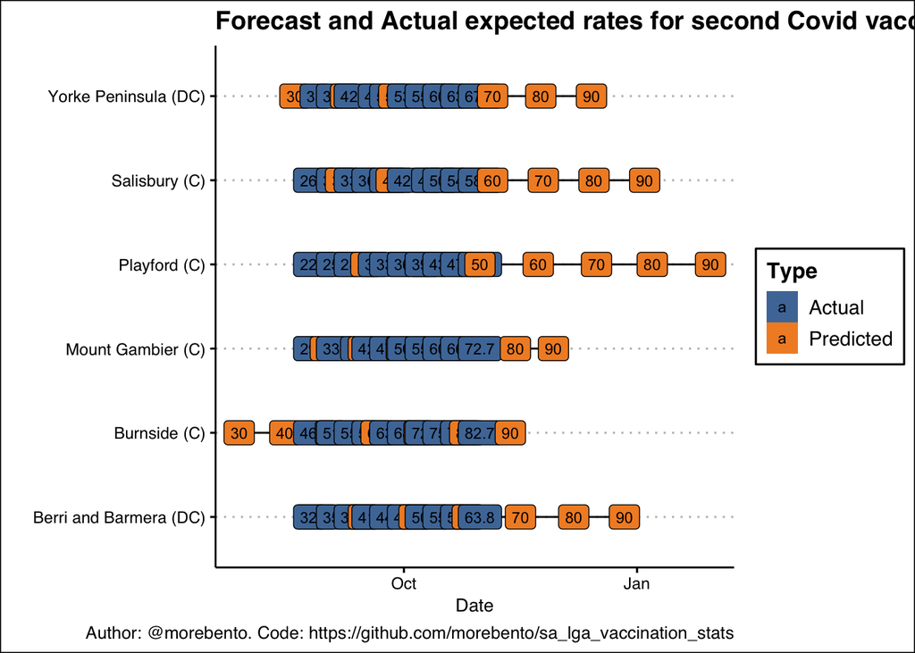

```r
combined_tbl %>%
    filter(
        abs_name %in% c("Playford (C)", "Burnside (C)", "Berri and Barmera (DC)", "Mount Gambier (C)", "Salisbury (C)", "Yorke Peninsula (DC)")
    ) %>%
    ggplot(aes(abs_name, date_as_at)) +
    geom_line() +
    geom_label(aes(label=air_second_dose_pct, fill = type), size=3) +
    theme_clean() +
    scale_fill_tableau() + # from ggthemes

    geom_hline(yintercept=as.numeric(as.Date("2021-11-23")), linetype="dashed") +
    coord_flip() +
    labs(
        title = "Forecast and Actual expected rates for second Covid vaccination % by SA LGA",
        caption =  plot_footer,
        y = "Date",
        x = "",
        fill = "Type"
    )
```

## 6.3 Forecast second dose % by LGA for 23 Nov Chart

This chart shows the spread of vaccination rates expected by the 23rd of November 2021, sorted by vaccination rate and coloured by whether the LGA has reached 80%. The population of the LGA, from the 2019 census is also included.

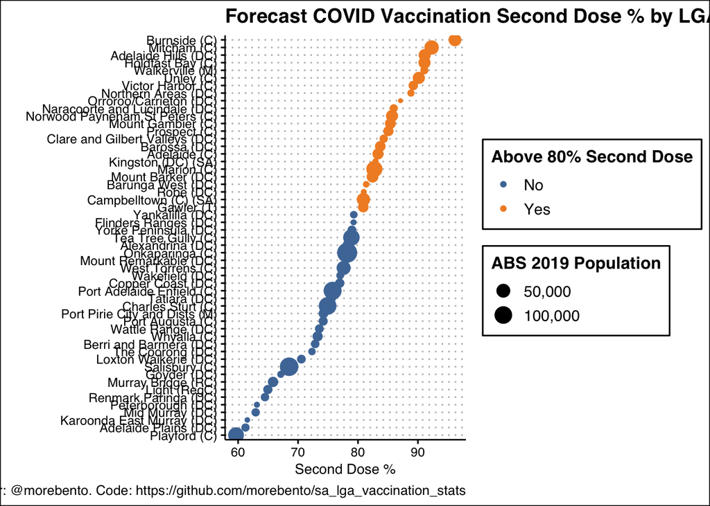

```r
# get population data
lga_pop_tbl <- read_csv("https://vaccinedata.covid19nearme.com.au/data/geo/air_lga.csv") %>%
    clean_names() %>%
    filter(state == "SA") %>%
    slice_max(date_as_at) %>%
    select(abs_name, abs_erp_2019_population)

# plot the chart
predicted_vax_rates_tidy_tbl %>%
    ungroup() %>%
    inner_join(lga_pop_tbl) %>%
    filter(
        abs_name != "Grant (DC)"
    ) %>%
    mutate(
        above_80 = if_else(air_second_dose_pct >= 80, "Yes", "No")
    ) %>%
    mutate(
        abs_name = fct_reorder(abs_name, air_second_dose_pct)
    ) %>%
    ggplot(aes(abs_name, air_second_dose_pct)) +
    geom_point(aes(colour=above_80, size=abs_erp_2019_population)) +
    scale_size_continuous(labels=comma) +
    theme_clean() +
    scale_colour_tableau() + # from ggthemes
    coord_flip() +
    labs(
        title = "Forecast COVID Vaccination Second Dose % by LGA for 23 November 2021",
        caption =  plot_footer,
        y = "Second Dose %",
        x = "",
        colour = "Above 80% Second Dose",
        size = "ABS 2019 Population"
    )
```

## 6.4 High risk LGAs for 23 Nov Chart

This chart displays the vaccination % of each LGA vs the population of that LGA, colour coded by whether they have reached 80%. Those that have been defined as potentiallly high risk (low vaccination %, higher population) are labelled particularly.

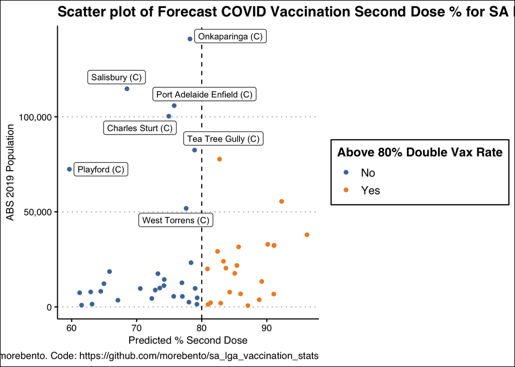

```r
# get high risk lgas, defined as those with vaccination < 80% and a population > 50k
high_risk_lgas <- predicted_vax_rates_tidy_tbl %>%
    inner_join(lga_pop_tbl) %>%
    filter(
        abs_erp_2019_population > 50000,
        air_second_dose_pct < 80
    ) %>%
    pull(abs_name)

# plot the chart - excluding the Grant District Council
predicted_vax_rates_tidy_tbl %>%
    filter(
        abs_name != "Grant (DC)"
    ) %>%
    inner_join(lga_pop_tbl) %>%
    mutate(
        above_80 = if_else(air_second_dose_pct >= 80, "Yes", "No")
    ) %>%
    select(abs_name, air_second_dose_pct, abs_erp_2019_population, above_80) %>%
    ggplot(aes(air_second_dose_pct, abs_erp_2019_population, label=abs_name)) +
    geom_point(aes(colour=above_80)) +
    scale_y_continuous(labels=comma_format()) +
    geom_vline(xintercept = 80, linetype="dashed") +
    geom_label_repel(data = subset(predicted_vax_rates_tidy_tbl %>% inner_join(lga_pop_tbl), abs_name %in% high_risk_lgas), size=3) +
    scale_colour_tableau() +
    theme_clean() +
    labs(
        title = "Scatter plot of Forecast COVID Vaccination Second Dose % for SA LGAs at 23 November 2021",
        caption =  plot_footer,
        y = "ABS 2019 Population",
        x = "Predicted % Second Dose",
        colour = "Above 80% Double Vax Rate"
    )
```

# 7 Conclusions